# Generating input data sets for mrgsolve

```r
library(mrgsolve)
library(dplyr)
```

# 1 Input data sets

An important mechanism for creating robust, complex simulations is the input data set. Input data sets specify the population of individuals to simulate, including the number of individuals, each individual’s dosing interventions, each individual’s covariate values etc. The input data set is just a plain old `R` `data.frame`, but with some expectations about which columns are present and expectations for how to handle columns for certain names. For example, every input data set has to have an `ID`, `time`, and `cmt` column. Note that either lower case names (like `time` and `cmt`) are acceptable as are upper case names (like `TIME` and `CMT`). But users are not to mix upper and lower case names (like `time` and `CMT`) for certain column names related to dosing events. The help topic `?data_set` discusses more about what the expectations are for input data sets.

# 2 Functions to generate input data sets

`mrgsolve` provides several functions and workflows to help you put together the right input data set for your simulation. The main point of this blog post is to review some of these functions to help you better organize your `mrgsolve` simulations. Some functions are very simple and you might not find a function to do **exactly** what you want to do. But we’ve found these functions to be helpful to accomplish tasks that we found ourselves repeating over and over … and thus these tasks were formalized in a function. Just keep in mind that input data sets are just `data.frames` … you can use any code or any function (even your own!) to do tasks similar to what these functions are doing.

## 2.1 `expand.ev`

`expand.ev` is like `expand.grid`: it creates a single `data.frame` with all combinations of it’s vector arguments. It’s pretty simple but convenient to have. For example,

```r
data <- expand.ev(amt=c(100,200,300), ID=1:3)
data
```

```
.   ID amt evid cmt time
. 1  1 100    1   1    0
. 2  2 200    1   1    0
. 3  3 300    1   1    0
. 4  4 100    1   1    0
. 5  5 200    1   1    0
. 6  6 300    1   1    0
. 7  7 100    1   1    0
. 8  8 200    1   1    0
. 9  9 300    1   1    0
```

This function call gives us 3 individuals at each of 3 doses. The `expand.grid` nature of `expand.ev` is what gives us `3x3=9` rows in the data set. Notice that the `IDs` are now 1 through 9 … `expand.ev` renumbers `IDs` so that there is only one dosing event per row and there is on row per `ID`.

Also notice that `time` defaults to 0, `evid` defaults to 1, and `cmt` defaults to 1. So, `expand.ev` fills in some of the required columns for you.

Let’s simulate with this data set:

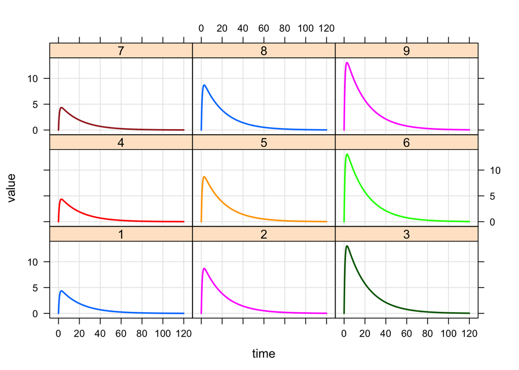

```r
mod <- mrgsolve:::house() %>% Req(CP)
mod %>%
  mrgsim(data=data) %>%
  plot(CP~time|factor(ID),scales="same")
```

## 2.2 `as_data_set`

This function allows you to combine several event objects into a single data sets. An example works best to illustrate.

First, create three event objects. Let’s try one `ID` at 100 mg, two `IDs` at 200 mg, and 3 `IDs` at 300 mg.

```r
e1 <- ev(amt=100, ID=1)
e2 <- ev(amt=200, ID=1:2)
e3 <- ev(amt=300, ID=1:3)
```

The events are

```r
e1
```

```
. Events:
.   ID time cmt amt evid
. 1  1    0   1 100    1
```

and

```r
e2
```

```
. Events:
.   ID time cmt amt evid
. 1  1    0   1 200    1
. 2  2    0   1 200    1
```

and

```r
e3
```

```
. Events:
.   ID time cmt amt evid
. 1  1    0   1 300    1
. 2  2    0   1 300    1
. 3  3    0   1 300    1
```

When we combine these events with `as_data_set` we get

```r
data <- as_data_set(e1,e2,e3)
data
```

```
.   ID time cmt evid amt
. 1  1    0   1    1 100
. 2  2    0   1    1 200
. 3  3    0   1    1 200
. 4  4    0   1    1 300
. 5  5    0   1    1 300
. 6  6    0   1    1 300
```

```r
load <- function(n) ev(amt=250, ID=1:n)
e1 <- load(1) + ev(amt=250, time=24, ii=24, addl=3, ID=1)
e2 <- load(2) + ev(amt=125, time=24, ii=12, addl=7, ID=1:2)
e3 <- load(3) + ev(amt=500, time=24, ii=48, addl=1, ID=1:3)
```

Now, `e1`, `e2`, and `e3` are more complex

```r
e1
```

```
. Events:
.   ID time cmt amt evid ii addl
. 1  1    0   1 250    1  0    0
. 2  1   24   1 250    1 24    3
```

```r
e3
```

```
. Events:
.   ID time cmt amt evid ii addl
. 1  1    0   1 250    1  0    0
. 4  1   24   1 500    1 48    1
. 2  2    0   1 250    1  0    0
. 5  2   24   1 500    1 48    1
. 3  3    0   1 250    1  0    0
. 6  3   24   1 500    1 48    1
```

But, we can still pull them together in one single data set

```r
data <- as_data_set(e1,e2,e3)
data
```

```
.    ID time cmt evid amt ii addl
. 1   1    0   1    1 250  0    0
. 2   1   24   1    1 250 24    3
. 3   2    0   1    1 250  0    0
. 4   2   24   1    1 125 12    7
. 5   3    0   1    1 250  0    0
. 6   3   24   1    1 125 12    7
. 7   4    0   1    1 250  0    0
. 8   4   24   1    1 500 48    1
. 9   5    0   1    1 250  0    0
. 10  5   24   1    1 500 48    1
. 11  6    0   1    1 250  0    0
. 12  6   24   1    1 500 48    1
```

An example simulation

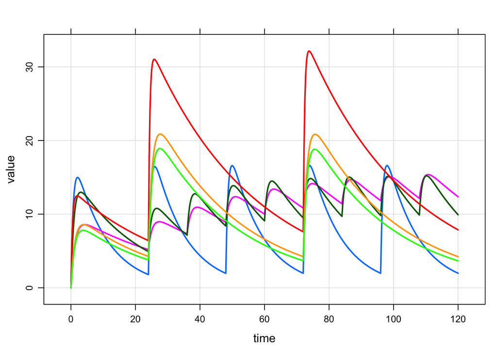

```r
set.seed(1112)
mod %>%
  omat(dmat(1,1,1,1)/10) %>%
  data_set(data) %>%
  mrgsim() %>%
  plot
```

## 2.3 `as.data.frame.ev`

Just a quick reminder here that you can easily convert between a single event object and a `data.frame`

```r
as.data.frame(e3)
```

```
.   ID time cmt amt evid ii addl
. 1  1    0   1 250    1  0    0
. 4  1   24   1 500    1 48    1
. 2  2    0   1 250    1  0    0
. 5  2   24   1 500    1 48    1
. 3  3    0   1 250    1  0    0
. 6  3   24   1 500    1 48    1
```

```r
as.ev(as.data.frame(e3))
```

```
. Events:
.   ID time cmt amt evid ii addl
. 1  1    0   1 250    1  0    0
. 4  1   24   1 500    1 48    1
. 2  2    0   1 250    1  0    0
. 5  2   24   1 500    1 48    1
. 3  3    0   1 250    1  0    0
. 6  3   24   1 500    1 48    1
```

So if you were building up an event object and just wanted to use it as a `data_set` or as a building block for a `data_set`, just coerce with `as.data.frame`.

## 2.4 `assign_ev`

This function assigns an intervention in the form of an event object to individuals in an `idata_set` according to a grouping column.

To illustrate, make a simple `idata_set`

```r
set.seed(8)
idata <- data_frame(ID=sample(1:6), arm=c(1,2,2,3,3,3))
idata
```

```
. # A tibble: 6 x 2
.      ID   arm
.   <int> <dbl>
. 1     3     1
. 2     6     2
. 3     4     2
. 4     1     3
. 5     5     3
. 6     2     3
```

Here, we have 6 `IDs`, one in arm 1, two in arm 2, three in arm 3. Let’s take the events from the previous example and assign them to the different arms.

```r
e1 <- ev(amt=250) + ev(amt=250, time=24, ii=24, addl=3)
e2 <- ev(amt=250) + ev(amt=125, time=24, ii=12, addl=7)
e3 <- ev(amt=250) + ev(amt=500, time=24, ii=48, addl=1)
assign_ev(list(e3,e2,e1),idata,"arm")
```

```
.    time cmt amt evid ii addl ID
. 1     0   1 250    1  0    0  3
. 2    24   1 500    1 48    1  3
. 3     0   1 250    1  0    0  6
. 4    24   1 125    1 12    7  6
. 5     0   1 250    1  0    0  4
. 6    24   1 125    1 12    7  4
. 7     0   1 250    1  0    0  1
. 8    24   1 250    1 24    3  1
. 9     0   1 250    1  0    0  5
. 10   24   1 250    1 24    3  5
. 11    0   1 250    1  0    0  2
. 12   24   1 250    1 24    3  2
```

Please look carefully at the input (`idata` and `list(e3,e2,e1)`); I have mixed it up a bit here to try to illustrate how things are assigned.

## 2.5 `ev_days`

This is a recently-added function (hint: you might need to install the latest version from GitHub to use this) that lets you schedule certain events on certain days of the week, repeating in a weekly cycle.

For example, to schedule 250 mg doses every Monday, Wednesday, and Friday for a month, you can do

```r
data <- ev_days(ev(amt=250, ID=1), days="m,w,f", addl=3)
data
```

```
.   ID time cmt amt evid  ii addl
. 1  1    0   1 250    1 168    3
. 2  1   48   1 250    1 168    3
. 3  1   96   1 250    1 168    3
```

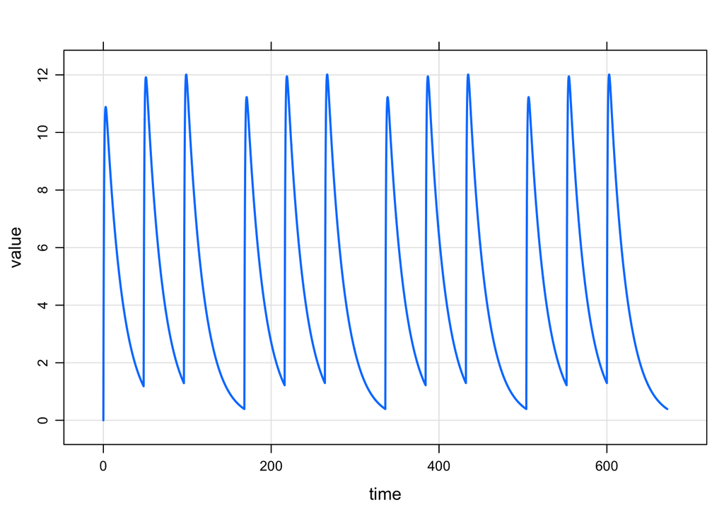

```r
mod %>% mrgsim(data=data, end=168*4) %>% plot
```

Or, you can do 100 mg doses on Monday, Wednesday, Friday, and 50 mg doses on Tuesday, Thursday, with drug holiday on weekends

```r
e1 <- ev(amt=100, ID=1)
e2 <- ev(amt=50,  ID=1)
data <- ev_days(m=e1, w=e1, f=e1, t=e2, th=e2, addl=3)
data
```

```
.   ID time cmt amt evid  ii addl
. 1  1    0   1 100    1 168    3
. 2  1   24   1  50    1 168    3
. 3  1   48   1 100    1 168    3
. 4  1   72   1  50    1 168    3
. 5  1   96   1 100    1 168    3
```

And simulate

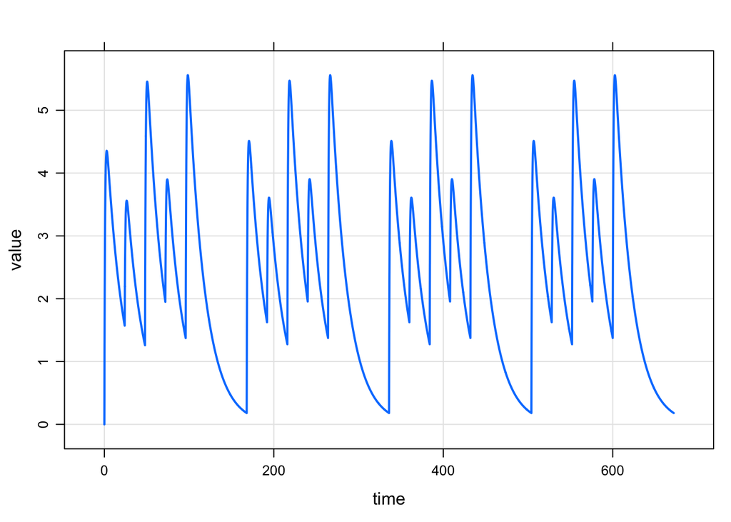

```r
mod %>% mrgsim(data=data,end=168*4) %>% plot
```

The same thing can be accomplished like this

```r
a <- ev_days(e1, days="m,w,f", addl=3)
b <- ev_days(e2, days="t,th",  addl=3)

c(as.ev(a),as.ev(b))
```

```
. Events:
.   ID time cmt amt evid  ii addl
. 1  1    0   1 100    1 168    3
. 4  1   24   1  50    1 168    3
. 2  1   48   1 100    1 168    3
. 5  1   72   1  50    1 168    3
. 3  1   96   1 100    1 168    3
```

You can use this as an event object or just coerce to `data.frame` to use as a `data_set`.

# 3 Create more compilcated regimens with event objects

```r
mod <- mread("pk2cmt", modlib()) %>% update(delta = 0.1) %>% Req(CP)
```

## 3.1 Event objects

Recall that event objects are our way of creating simple dosing interventions. They are created with the `ev` function and they look like a single dosing row from a data set.

For example, we can have 100 mg daily dosing over a week like this

```r
e1 <- ev(amt = 100, ii = 24, addl = 6)
e1
```

```
. Events:
.   time cmt amt ii addl evid
. 1    0   1 100 24    6    1
```

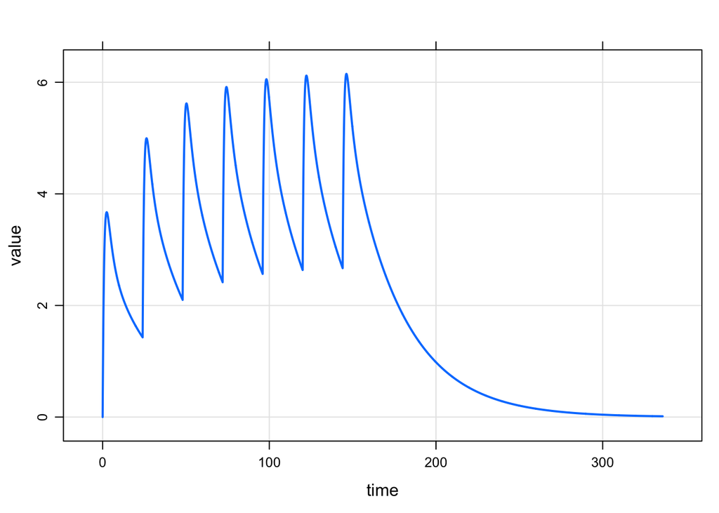

```r
mod %>% mrgsim(events = e1, end = 2*168) %>% plot
```

## 3.2 Sequences of event objects

Now, let’s imagine a alternating dosing sequence of 100 mg daily for a week, then 200 mg daily for a week etc. We can schedule this with a sequence of event objects.

First, make the 200 mg event object

```r
e2 <- ev(amt = 200, ii = 24, addl = 6)
```

Then, schedule them in a sequence

```r
e3 <- seq(e1, e2, e1)
e3
```

```
. Events:
.   time cmt amt ii addl evid
. 1    0   1 100 24    6    1
. 2  168   1 200 24    6    1
. 3  336   1 100 24    6    1
```

When we create a sequence of event objects, `mrgsolve` calculates when each event is finished and automatically times each event according to the end time from the preceeding event. Notice that each event starts one dosing interval after the last dose of the previous event.

And try that out

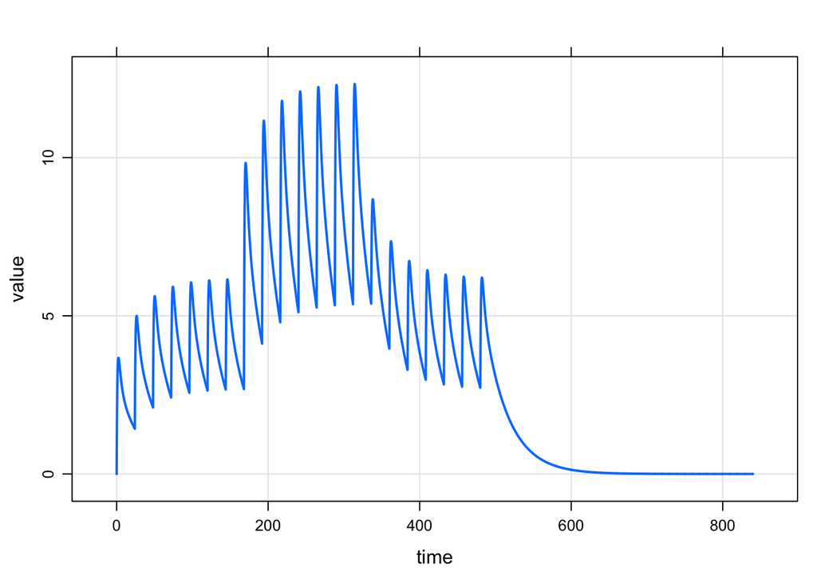

```r
mod %>% mrgsim(events = e3, end = 5*168) %>% plot
```

### 3.2.1 Using `wait` in event sequence

What if we want a 3-day holiday between each treatment period? Simply schedule a waiting period in the sequence:

```r
e4 <- seq(e1, wait = 72, e2, wait = 72, e1)
e4
```

```
. Events:
.   time cmt amt ii addl evid
. 1    0   1 100 24    6    1
. 2  240   1 200 24    6    1
. 3  480   1 100 24    6    1
```

Notice that the event objects (`e1` and `e2`) are unnamed arguments. But `wait` is a named argument with a single numeric value. Introducing a `wait` period in the sequence pushes the start of the next period in the sequence forward in time.

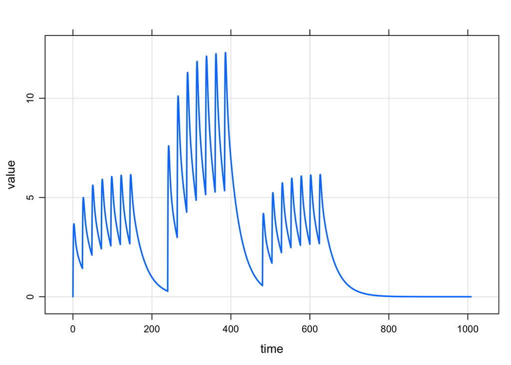

```r
mod %>% mrgsim(events = e4, end = 6*168) %>% plot
```

To code a cycle of 3 weeks on, one week off for two months

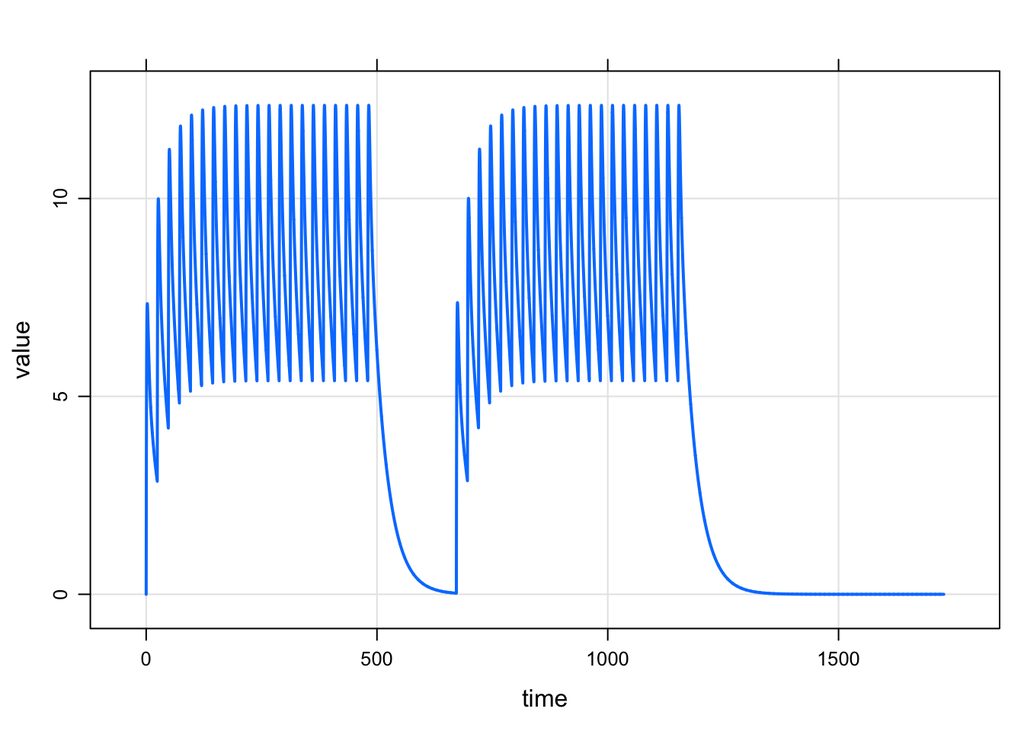

```r
e5 <- ev(amt = 200, ii = 24, addl = 20)

e6 <- seq(e5, wait = 168, e5)

mod %>% mrgsim(events = e6, end = 72*24) %>% plot
```

## 3.3 Repeating a complicated regimen

Coding the 3 weeks on / 1 week off regimen for 2 months wasn’t too bad, but it might get tedious if we need to do it for a year.

To make that simpler we can repeat the basic regimen as many times as we’d like with `ev_rep`

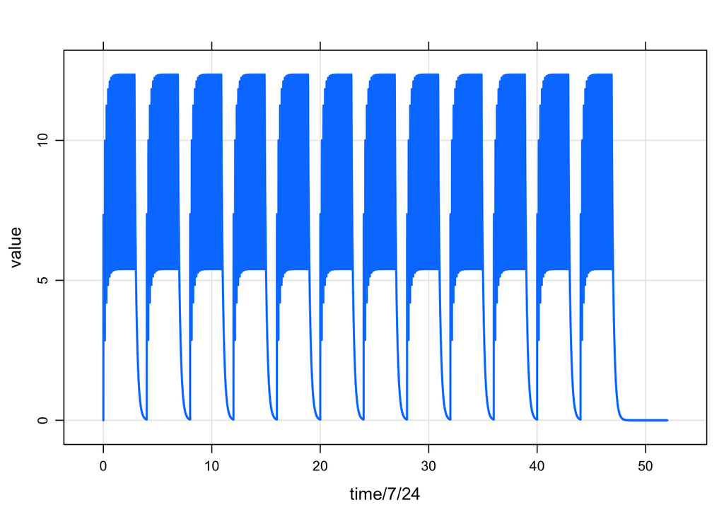

```r
e7 <- ev_rep(e5, n = 12, wait = 168)

mod %>% mrgsim(data = e7, end = 52*168) %>% plot(CP~time/7/24)
```

In `ev_rep`, there is a single `wait`ing period in between replicates of the 3 week on period.

Alternatively, we could work with the 100/200/100 sequence like this

```r
e4
```

```
. Events:
.   time cmt amt ii addl evid
. 1    0   1 100 24    6    1
. 2  240   1 200 24    6    1
. 3  480   1 100 24    6    1
```

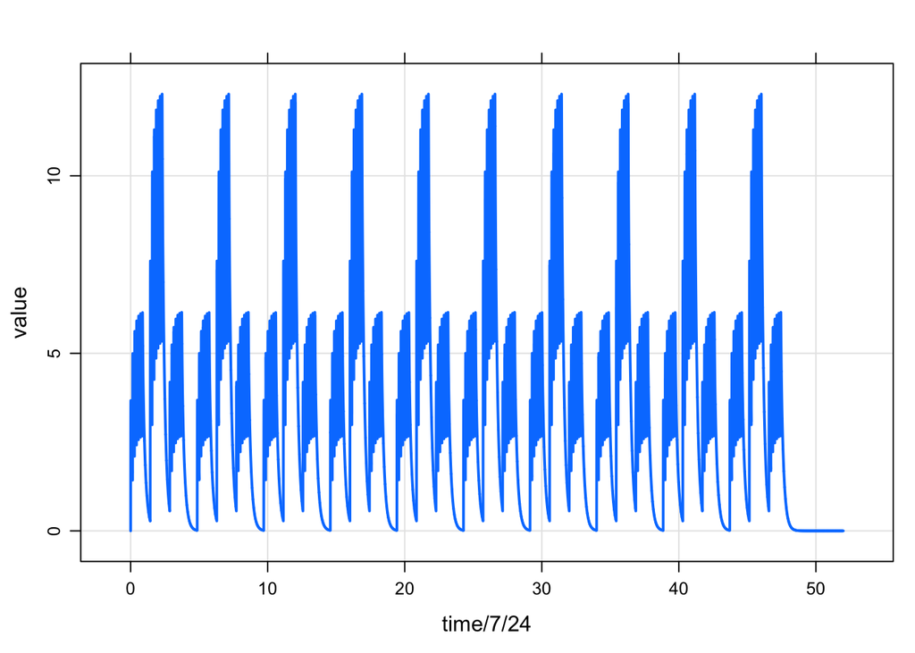

```r
e8 <- ev_rep(e4, n = 10, wait = 168)
mod %>% mrgsim(data = e8, end = 52*168) %>% plot(CP~time/7/24)
```

## 3.4 Expand an event into a population

So far we have been dealing with a single ID in the event object or data set. The `ev_rep` function can easily expand that event in to several IDs

```r
e9 <- seq(e1, wait = 72, e2)
e9 <- ev_rep(e9, id = 1:5)
e9
```

```
.    time cmt amt ii addl evid ID
. 1     0   1 100 24    6    1  1
. 2   240   1 200 24    6    1  1
. 3     0   1 100 24    6    1  2
. 4   240   1 200 24    6    1  2
. 5     0   1 100 24    6    1  3
. 6   240   1 200 24    6    1  3
. 7     0   1 100 24    6    1  4
. 8   240   1 200 24    6    1  4
. 9     0   1 100 24    6    1  5
. 10  240   1 200 24    6    1  5
```

Now we have 5 patients each getting 100 mg daily for one week and then 200 mg daily for a week after a 3 day break.

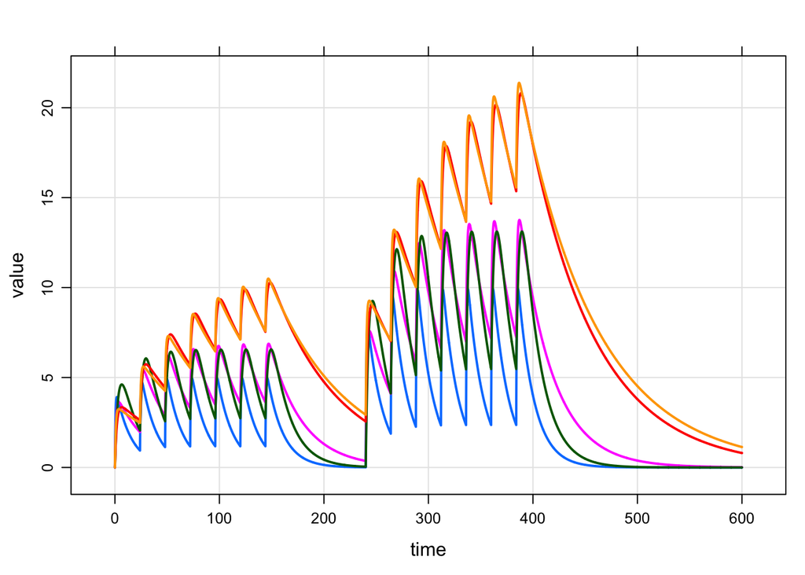

```r
mod <- mread("popex", modlib()) %>% update(delta=0.1)
mod %>% mrgsim(data = e9, end = 600) %>% plot(DV~.)
```

## 3.5 Filter input data set inline

Remember, when you pass in your input data set via `data_set`, you can filter in line:

```r
data <- expand.ev(amt=c(100,200,300))
mod %>% data_set(data, amt==300) %>% Req(GUT,CP) %>% mrgsim
```

```
. Model:  popex.cpp
. Dim:    2402 x 3
. Time:   0 to 240
. ID:     1
.      ID time   GUT
. [1,]  3  0.0   0.0
. [2,]  3  0.0 300.0
. [3,]  3  0.1 286.3
. [4,]  3  0.2 273.2
. [5,]  3  0.3 260.7
. [6,]  3  0.4 248.8
. [7,]  3  0.5 237.5
. [8,]  3  0.6 226.6
```